# BSE Statistics

(1) Total: (19pt). 1pt for $a$, 6pt for $f_X(x)$, 6pt for $E(X)$, 6pt for $Var(X)$.

$$\begin{aligned}
F_X(10+2a)&=0.4\cdot2a/2=1,\quad a=2.5
\end{aligned}$$

$$\begin{aligned}
f_X(x)=
\left\{ \begin{array}{ll}
0.4/2.5\cdot(x-10) & & 10\leq x< 12.5,\\
0.4 - 0.4/2.5\cdot(x-12.5) & & 12.5\leq x<15,\\
0 & & \text{o.w.}
\end{array} \right.
\end{aligned}$$

$$\begin{aligned}
E(X)
&=\int^{\infty}_{-\infty}xf_X(x)dx\\
&=\int^{12.5}_{10} x\cdot0.4/2.5\cdot(x-10)dx+\int^{15}_{12.5} x\cdot(0.4 - 0.4/2.5\cdot(x-12.5))dx\\
&=5.833333 + 6.666667\\
&=12.5
\end{aligned}$$

```r
integrate(function(x) {x * 0.4/2.5 * (x - 10)}, 10, 12.5)$value + integrate(function(x) {x * (0.4 - 0.4 / 2.5 * (x - 12.5))}, 12.5, 15)$value
```

```
#> [1] 12.5
```

Or we can say that since the distribution is symmetric at $b$, the mean of the distribution is $b$.

$$\begin{aligned}
Var(X)
&=E((X-E(X))^2)\quad \text{(法一)}\\
&=\int^{\infty}_{-\infty}(x-E(X))^2f_X(x)dx\\
&=\int^{12.5}_{10} (x-12.5)^2\cdot0.4/2.5\cdot(x-10)dx+\int^{15}_{12.5} (x-12.5)^2\cdot(0.4 - 0.4/2.5\cdot(x-12.5))dx\\
&=E(X^2) - E(X)^2\quad \text{(法二)}\\
&=\int^{12.5}_{10} x^2\cdot0.4/2.5\cdot(x-10)dx+\int^{15}_{12.5} x^2\cdot(0.4 - 0.4/2.5\cdot(x-12.5))dx-12.5^2\\
&=1.04
\end{aligned}$$

```r
# 法一
integrate(function(x) {(x - 12.5)^2 * 0.4/2.5 *(x - 10)}, 10, 12.5)$value + integrate(function(x) {(x - 12.5)^2 * (0.4 - 0.4 / 2.5 * (x - 12.5))}, 12.5, 15)$value
```

```
#> [1] 1.041667
```

```r
# 法二
integrate(function(x) {x^2 * 0.4/2.5 * (x - 10)}, 10, 12.5)$value + integrate(function(x) {x^2 * (0.4 - 0.4 / 2.5 * (x - 12.5))}, 12.5, 15)$value - 12.5^2
```

```
#> [1] 1.041667
```

(2) (3pt)

$$\begin{aligned}
f_Y(y)=
\left\{ \begin{array}{ll}
f_X(y)/0.5 = (0.4 - 0.4/2.5\cdot(y-12.5))/0.5 && 12.5\leq y< 15,\\
0 && \text{o.w.}
\end{array} \right.
\end{aligned}$$

(3) Total: (6pt). 3pt for mean, 3pt for variance.

$$\begin{aligned}
E(Y)
&=\int^{\infty}_{-\infty}yf_Y(y)dy\\
&=\int^{15}_{12.5} y\cdot(0.4 - 0.4/2.5\cdot(y-12.5))/0.5dy\\
&=13.33
\end{aligned}$$

```r
integrate(function(x) {x * (0.4 - 0.4 / 2.5 * (x - 12.5)) / 0.5}, 12.5, 15)$value
```

```
#> [1] 13.33333
```

$$\begin{aligned}
Var(Y)
&=E((Y-E(Y))^2)\quad \text{(法一)}\\
&=\int^{\infty}_{-\infty}(y-E(Y))^2f_Y(y)dy\\
&=\int^{15}_{12.5} (y-12.5)^2\cdot(0.4 - 0.4/2.5\cdot(y-12.5))/0.5\ dy\\
&=E(Y^2) - E(Y)^2\quad \text{(法二)}\\
&=\int^{15}_{12.5} y^2\cdot(0.4 - 0.4/2.5\cdot(y-12.5))/0.5\ dy-13.33333^2\\
&=0.35
\end{aligned}$$

```r
# 法一
integrate(function(x) {(x - 13.3333)^2 * (0.4 - 0.4 / 2.5 * (x - 12.5)) / 0.5}, 12.5, 15)$value
```

```
#> [1] 0.3472222
```

```r
# 法二
integrate(function(x) {x^2 * (0.4 - 0.4 / 2.5 * (x - 12.5)) / 0.5}, 12.5, 15)$value - 13.3333^2
```

```
#> [1] 0.3481111
```

5. (26pt)

(1) (8pt)

Let $X_1,X_2,\dots,X_n$ be random variables of n independent unit step.

$$\begin{aligned}
&P(X_i=1)=p,\\
&P(X_i=-1)=1-p,\\
\end{aligned}$$

for $i=1,2,\dots,n$.

Let $X$ be the position after $n$ steps.

$$\frac{X+n}{2}=\frac{\sum^n_{i=1} X_i+n}{2}=\sum^n_{i=1}\Big(\frac{X_i+1}{2}\Big)$$

Note that for $i=1,2,\dots,n$,

$$\begin{aligned}
&P(\frac{X_i+1}{2}=1)=p,\\
&P(\frac{X_i+1}{2}=0)=1-p.
\end{aligned}$$

That is, $\frac{X_i+1}{2}\sim\text{Bernoulli}(p)$, for $i=1,2,\dots,n$. Moreover, $\frac{X+n}{2}$ represents the number of successes that occur in the $n$ independent trials, and the following shows that it is said to be a binomial random variable with parameters $(n,p)$.

$$\begin{aligned}
P(\frac{X+n}{2}=k)
&=P\Bigg(\sum^n_{i=1}\Big(\frac{X_i+1}{2}\Big)=k\Bigg)\\
&=P\Bigg(\Big(\frac{X_i+1}{2}\Big)=k_i,\ i=1,2,\dots,n\ \Big|\sum^n_{i=1}k_i=k, k_i\in(0,1),\ i=1,2,\dots,n\Bigg)\\
&={n\choose k}p^k(1-p)^{n-k},
\end{aligned}$$

for $k=0,1,\dots,n$.

$\frac{X+n}{2}\sim\text{Binomial}(n,p)$

(2) Total: (5pt). 4pt for proof, 1pt for the rest.

Use the fact that $E(aX+b)=aE(X)+b$.

$$\begin{aligned}
E(\frac{X+n}{2})&=\frac{1}{2}(E(X)+n)=np\\
E(X)&=2np-n
\end{aligned}$$

(3) Total: (5pt). 4pt for proof, 1pt for the rest.

Use the fact that $Var(aX+b)=a^2Var(X)$.

$$\begin{aligned}
Var(\frac{X+n}{2})&=(\frac{1}{2})^2(Var(X))=np(1-p)\\
Var(X)&=4np(1-p)
\end{aligned}$$

The prove of the expectation and variance of a binomial random variable.

Let $X\sim\text{Binomial}(n,p)$

$$\begin{aligned}
E[X^k]
&= \sum_{i=0}^n i^k {n \choose i}p^i(1-p)^{n-i}\\
&= \sum_{i=1}^n i^k {n \choose i}p^i(1-p)^{n-i}\\
&= \sum_{i=1}^n i^k \frac{n}{i}{n-1 \choose i-1}p^i(1-p)^{n-i}\\
&= np\sum_{i=1}^n i^{k-1}{n-1 \choose i-1}p^{i-1}(1-p)^{n-i}\\
&= np\sum_{i=0}^{n-1} (i+1)^{k-1}{n-1 \choose i}p^i(1-p)^{n-i-1}\\
&= npE[(Y+1)^{k-1}]
\end{aligned}$$

where $Y\sim Binom(n-1,p)$.

$$\begin{aligned}
E[X]
&= npE[1]\\
&= np
\end{aligned}$$

$$\begin{aligned}
E[X^2]
&= npE[Y+1]\\
&= np((n-1)p+1)\\
Var(X)
&= np((n-1)p+1)-(np)^2\\
&= -np^2+np\\
&= np(1-p)
\end{aligned}$$

(4) (3pt)

Previously we know that

$$\begin{aligned}
P(\frac{X+n}{2}=k)
&={n\choose k}p^k(1-p)^{n-k},
\end{aligned}$$

and then given $p=0.6$ and $n=20$ we can derive that

$$\begin{aligned}
P(X>8)
&=P(\frac{X+20}{2}>(8+20)/2)\\
&=\sum^{20}_{k=15}{20\choose k}0.6^k(1-0.6)^{20-k}\\
&=0.1256\\
P(X< -8)
&=P(\frac{X+20}{2}<(-8+20)/2)\\
&=\sum^{5}_{k=0}{20\choose k}0.6^k(1-0.6)^{20-k}\\
&=0.0016\\
P(X>8)&+P(X< -8)=0.1272
\end{aligned}$$

```r
sum(dbinom(c(0:5, 15:20), 20, 0.6))
```

```
#> [1] 0.1272105
```

(5) (5pt)

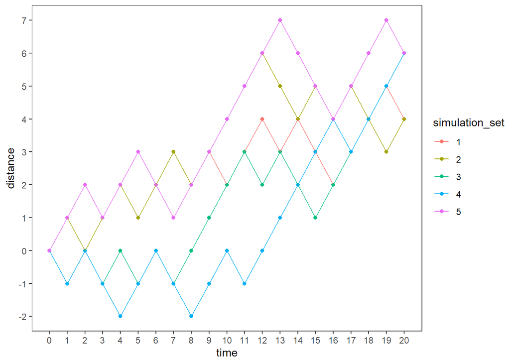

```r
df = tibble(
  simulation_set = factor(rep(1:5, each = 21)),
  n = rep(0:20, times = 5),
  move = map_dbl(n, ~ case_when(
    .x == 0 ~ 0,
    TRUE ~ sample(c(-1, 1), 1, prob = c(1 - 0.6, 0.6))
  )),
) %>%
  group_by(simulation_set) %>%
  mutate(position = cumsum(move))

ggplot(df, aes(n, position, color = simulation_set)) +
  geom_point() +
  geom_line() +
  scale_x_continuous(name = "time", breaks = seq(0, 20, 1)) +
  scale_y_continuous(name = "distance", breaks = seq(-20, 20, 1)) +
  theme_test()
```

6. (14pt)

(1) (3pt)

WLOG, let $b=0$ and we can know what $a$ is.

$$\begin{aligned}
1&=\int^1_{-1}a\sqrt{1-x^2}dx\\
&=a(\frac{x}{2}\sqrt{1-x^2}+\frac{1}{2}\sin^{-1}x)|^1_{-1}\\
&=\frac{a\pi}{2},\\
a&=\frac{2}{\pi}
\end{aligned}$$

(2) (2pt)

$$\begin{aligned}
f_Y(y)=
\left\{ \begin{array}{ll}
2\frac{2}{\pi}\sqrt{1-(x-b)^2} && b\leq x\leq b+1,\\
0 && \text{o.w.}
\end{array} \right.
\end{aligned}$$

(3) (7pt) 1pt for the mean, 6pt for the variance.

Since $X$ is symmetric, we know that $E(X)=b$ trivially.

$$\begin{aligned}
Var(X)
&=E((X-E(X))^2)\\
&=E((X-b)^2)\\
&=\int^{b+1}_{b-1}(x-b)^2a\sqrt{1-(x-b)^2}dx\\
\text{let }&y=x-b,\ dy=dx\\
&=\int^{1}_{-1}y^2a\sqrt{1-y^2}dy\\
&=\frac{a}{8}(\sin^{-1}(1)-\sin^{-1}(-1))\\
&=\frac{a\pi}{8}\\
&=\frac{2}{\pi}\frac{\pi}{8}
\end{aligned}$$

(4) (2pt)

$$\begin{aligned}
Z&=5+3(X-b)=3X+5-3b\\
E(Z)&=E(3X+5-3b)\\
&=3E(X)+5-3b\\
&=3b+5-3b\\
&=5\\
Var(Z)&=Var(3X+5-3b)\\
&=9Var(X)\\
&=\frac{9}{4}
\end{aligned}$$

7. (40pt)

(1) Total: (32pt). Each of the r.v., we get 1pt for the highest density, 6 pt for the p.d.f., 6pt for the c.d.f, 3pt for the plot.

$$\begin{aligned}
F_X(15)&=15f_X(5)/2=1\\
f_X(5)&=\frac{2}{15}\\
f_X(x)&=
\left\{ \begin{array}{ll}
\frac{2}{15}\frac{1}{5}x && 0\leq x<5,\\
\frac{2}{15}-\frac{2}{15}\frac{1}{10}(x-5)=\frac{1}{5}-\frac{x}{75} && 5\leq x<15,\\
0 && \text{o.w.}
\end{array} \right.\\
F_X(x)&=
\left\{ \begin{array}{ll}
\frac{1}{75}x^2 && 0\leq x<5,\\
F_X(5)+\int^x_5(\frac{2}{15}-\frac{2}{15}\frac{1}{10}(x-5))=-\frac{1}{2}+\frac{x}{5}-\frac{x^2}{150} && 5\leq x<15,\\
1 && \text{o.w.}
\end{array} \right.
\end{aligned}$$

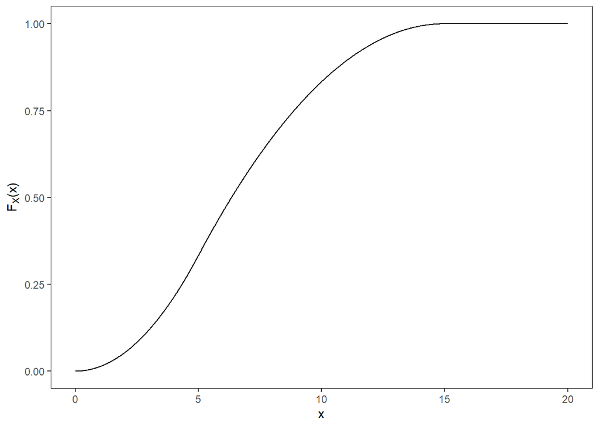

```r
F_X = function(x) {
  case_when(
    x >= 0 & x < 5 ~ x^2 / 75,
    x >= 5 & x < 15 ~ -1 / 2 + x / 5 - x^2 / 150,
    x >= 15 ~ 1,
    TRUE ~ 0
  )
}
df = tibble(
  x = seq(0, 20, 0.01),
  F_x = F_X(x),
)
ggplot(df, aes(x, F_x)) +
  geom_line() +
  scale_x_continuous(breaks = c(0, 5, 10, 15, 20), name = "x") +
  scale_y_continuous(limits = c(0, 1.0001), name = latex2exp::TeX("$\\F_X(x)$")) +
  theme_test()
```

$$\begin{aligned}
F_Y(15)&=10f_Y(10)/2=1\\
f_Y(10)&=\frac{1}{5}\\
f_Y(y)&=
\left\{ \begin{array}{ll}
\frac{1}{5}\frac{1}{5}(y-5)=\frac{1}{25}(y-5) && 5\leq y<10,\\
\frac{1}{5}-\frac{1}{5}\frac{1}{5}(y-10)=\frac{3}{5}-\frac{1}{25}y && 10\leq y<15,\\
0 && \text{o.w.}
\end{array} \right.\\
F_Y(y)&=
\left\{ \begin{array}{ll}
\frac{y^2}{50}-\frac{y}{5}+\frac{1}{2} && 5\leq y<10,\\
F_Y(10)+\int^y_{10}(\frac{3}{5}-\frac{1}{25}y)=\frac{-y^2}{50}+\frac{3y}{5}-\frac{7}{2} && 10\leq y<15,\\
1 && \text{o.w.}
\end{array} \right.
\end{aligned}$$

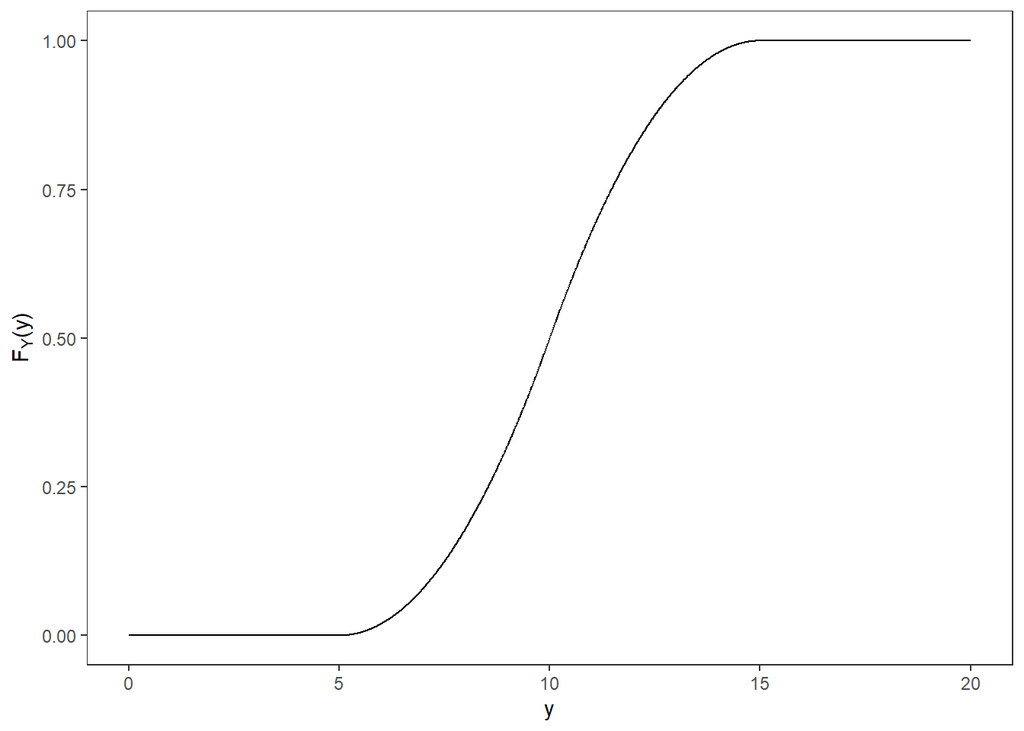

```r
F_Y = function(y) {
  case_when(
    y >= 5 & y < 10 ~ y^2 / 50 - y / 5 + 1 / 2,
    y >= 10 & y < 15 ~ -y^2 / 50 + 3 * y / 5 - 7 / 2,
    y >= 15 ~ 1,
    TRUE ~ 0
  )
}
df = tibble(
  y = seq(0, 20, 0.01),
  F_y = F_Y(y),
)
ggplot(df, aes(y, F_y)) +
  geom_line() +
  scale_x_continuous(breaks = c(0, 5, 10, 15, 20), name = "y") +
  scale_y_continuous(limits = c(0, 1.0001), name = latex2exp::TeX("$\\F_Y(y)$")) +
  theme_test()
```

(2) (8pt)

$$\begin{aligned}
P(X>Y)
&=\int P(X>y|y)f_Y(y)dy\\
&=\int^{15}_5\Big(\int^{15}_yf_X(x)dx\Big)f_Y(y)dy\\
&=\int^{10}_5\Big(\int^{15}_yf_X(x)dx\Big)f_Y(y)dy+\int^{15}_{10}\Big(\int^{15}_yf_X(x)dx\Big)f_Y(y)dy\\
&=\int^{10}_5\Big(\int^{15}_y\frac{1}{5}-\frac{x}{75}dx\Big)(\frac{1}{25}(y-5))dy+\int^{15}_{10}\Big(\int^{15}_y\frac{1}{5}-\frac{x}{75}dx\Big)(\frac{3}{5}-\frac{y}{25})dy\\
&=\int^{10}_5(\frac{3}{2}-\frac{y}{5}+\frac{y^2}{150})(-\frac{1}{5}+\frac{y}{25})dy+\int^{15}_{10}(\frac{3}{2}-\frac{y}{5}+\frac{y^2}{150})(\frac{3}{5}-\frac{y}{25})dy\\
&=0.19
\end{aligned}$$

```r
integrate(function(y) {(3 / 2 - y / 5 + y^2 / 150) * (-1 / 5 + y / 25)}, 5, 10)$value +
  integrate(function(y) {(3 / 2 - y / 5 + y^2 / 150) * (3 / 5 - y / 25)}, 10, 15)$value
```

```
#> [1] 0.1944444
```

## 1.3 Appendix: All code for HW2

```r
knitr::opts_chunk$set(echo = FALSE)
knitr::opts_chunk$set(echo = TRUE, comment = "#>", cache = TRUE)
# 3.1
x = c(-43.5615, -42.5594, -27.5556, -24.8670, -7.6353,
      -16.6590, -30.3863, -13.9924, -48.8766, -40.9939,
      -38.2022, -8.6007, -26.9491, -41.7347, -20.3306,
      -16.6453, -8.1240, -6.7680, -14.3989, -37.0406,
      -0.8470, -18.0262, -20.5075, -25.0793, -16.8221,
      -7.7765, 14.4545, 35.3056, 33.6065, -0.1143,
      -0.5319, 7.5514, -0.4998, 14.1964, -0.1449,
      11.8305, 22.5281, 29.9923, 40.7217, 14.2982,
      23.3038, 20.4037, 17.2357, 43.1575, 34.5701,
      33.7827, 31.9995, 23.4265, 18.9954, 13.7399)
# TODO: calculate mean and standard deviation of `x`

# 4.1
x = c(-5.407, -64.317, -18.434, 24.298, -38.989,
      -6.800, -43.550, 31.181, -23.789, -8.363,
      59.050, 32.460, -8.182, -20.621, 14.489,
      -20.165, 2.946, 13.432, 33.898, -43.162,
      -35.052, 46.106, 14.658, 21.340, 13.584,
      16.901, 16.977, 23.161, -38.092, -16.026,
      17.982, 15.979, -20.913, 17.966, 43.496,
      -17.282, -16.295, 9.455, -6.092, -3.146,
      19.561, -37.615, -1.747, -44.600, -38.186,
      -1.586, 65.115, 4.176, 5.509, 38.330)
# TODO: calculate mean and standard deviation of `x`

# 5.1
library(tidyverse)
# TODO: `constant` is the constant c in the question, you have to prove c at first
constant = ____
n = 10000 # target random sample size
# TODO: fill in the number of random sample
df = tibble(
  rexp = rexp(____, 1),
  dexp = constant * dexp(rexp, 1),
  runif = runif(____, min = 0, max = dexp),
  dnorm = 2 * dnorm(rexp),
  reject = dnorm < runif
)
# after filter those not rejected random samples, which represent sampling from truncated normal distribution,
samples = df %>%
  filter(reject == FALSE) %>%
  pull(rexp)
# TODO: you need to give positive or negative sign randomly to random samples
samples = samples[1:n] * sample(c(1, -1), size = n, replace = TRUE)
# TODO: calculate the mean and variance
# TODO: plot the histogram

# Additional code (not necessary to submit)
# demonstrate the acceptance-rejection method
ggplot(df) +
  geom_point(aes(rexp, runif, colour = reject), size = .01) +
  geom_line(aes(rexp, dexp), colour = "darkgreen") +
  geom_line(aes(rexp, dnorm), colour = "darkorange") +
  scale_colour_manual(values = c("lightgoldenrod", "lightgreen"), guide = FALSE) +
  labs(x = "", y = "") +
  theme_classic()
knitr::opts_chunk$set(echo = TRUE, comment = "#>", cache = TRUE)
library(tidyverse)
library(lubridate)
library(scales)
library(knitr)
cubes = rep(c("red", "yellow", "blue"), c(22, 15,13))

sample_space = cubes[which(cubes != "blue")]
# or equivalently,
# sample_space = cubes[which(!cubes %in% "blue")]
# sample_space = cubes[!cubes %in% "blue"]
sample(sample_space, size = 10, replace = TRUE)
sample(sample_space, size = 10, replace = FALSE)
# or equivalently,
# sample(sample_space, size = 10)
f_Z = function(z) {
  case_when(
    z >= 5 & z < 12 ~ 2 / 735 * z - 2 / 147,
    z >= 12 & z < 15 ~ -1 / 1470 * z + 4 / 147,
    z >= 15 & z < 35 ~ 29 / 29400 * z + 13 / 5880,
    z >= 35 & z < 40 ~ -23 / 9800 * z + 233 / 1960,
    z >= 40 & z < 55 ~ -1 / 600 * z + 11 / 120,
    TRUE ~ 0
  )
}
df = tibble(
  z = seq(0, 80, 0.1),
  f_z = f_Z(z),
  F_z = map_dbl(z, ~ integrate(f_Z, 0, .x)$value)
)
ggplot(df, aes(z, f_z)) +
  geom_line() +
  geom_vline(xintercept = c(12, 15, 35, 40), linetype = "dotted") +
  scale_x_continuous(breaks = c(5, 12, 15, 35, 40, 55), name = "z") +
  scale_y_continuous(limits = c(0, 0.1), name = latex2exp::TeX("$\\f_Z(z)$")) +
  theme_test()
# continous code in (1), or separate the c.d.f as follows
# df = df %>%
#   mutate(F_z = map_dbl(z, ~ integrate(f_Z, 0, .x)$value))
ggplot(df, aes(z, F_z)) +
  geom_line() +
  geom_vline(xintercept = c(12, 15, 35, 40), linetype = "dotted") +
  scale_x_continuous(breaks = c(5, 12, 15, 35, 40, 55), name = "z") +
  scale_y_continuous(limits = c(0, 1.0001), name = latex2exp::TeX("$\\F_Z(z)$")) +
  theme_test()
integrate(function(x) {x * 0.4/2.5 * (x - 10)}, 10, 12.5)$value + integrate(function(x) {x * (0.4 - 0.4 / 2.5 * (x - 12.5))}, 12.5, 15)$value
# 法一
integrate(function(x) {(x - 12.5)^2 * 0.4/2.5 *(x - 10)}, 10, 12.5)$value + integrate(function(x) {(x - 12.5)^2 * (0.4 - 0.4 / 2.5 * (x - 12.5))}, 12.5, 15)$value
# 法二
integrate(function(x) {x^2 * 0.4/2.5 * (x - 10)}, 10, 12.5)$value + integrate(function(x) {x^2 * (0.4 - 0.4 / 2.5 * (x - 12.5))}, 12.5, 15)$value - 12.5^2
integrate(function(x) {x * (0.4 - 0.4 / 2.5 * (x - 12.5)) / 0.5}, 12.5, 15)$value
# 法一
integrate(function(x) {(x - 13.3333)^2 * (0.4 - 0.4 / 2.5 * (x - 12.5)) / 0.5}, 12.5, 15)$value
# 法二
integrate(function(x) {x^2 * (0.4 - 0.4 / 2.5 * (x - 12.5)) / 0.5}, 12.5, 15)$value - 13.3333^2
sum(dbinom(c(0:5, 15:20), 20, 0.6))
df = tibble(
  simulation_set = factor(rep(1:5, each = 21)),
  n = rep(0:20, times = 5),
  move = map_dbl(n, ~ case_when(
    .x == 0 ~ 0,
    TRUE ~ sample(c(-1, 1), 1, prob = c(1 - 0.6, 0.6))
  )),
) %>%
  group_by(simulation_set) %>%
  mutate(position = cumsum(move))

ggplot(df, aes(n, position, color = simulation_set)) +
  geom_point() +
  geom_line() +
  scale_x_continuous(name = "time", breaks = seq(0, 20, 1)) +
  scale_y_continuous(name = "distance", breaks = seq(-20, 20, 1)) +
  theme_test()
F_X = function(x) {
  case_when(
    x >= 0 & x < 5 ~ x^2 / 75,
    x >= 5 & x < 15 ~ -1 / 2 + x / 5 - x^2 / 150,
    x >= 15 ~ 1,
    TRUE ~ 0
  )
}
df = tibble(
  x = seq(0, 20, 0.01),
  F_x = F_X(x),
)
ggplot(df, aes(x, F_x)) +
  geom_line() +
  scale_x_continuous(breaks = c(0, 5, 10, 15, 20), name = "x") +
  scale_y_continuous(limits = c(0, 1.0001), name = latex2exp::TeX("$\\F_X(x)$")) +
  theme_test()
F_Y = function(y) {
  case_when(
    y >= 5 & y < 10 ~ y^2 / 50 - y / 5 + 1 / 2,
    y >= 10 & y < 15 ~ -y^2 / 50 + 3 * y / 5 - 7 / 2,
    y >= 15 ~ 1,
    TRUE ~ 0
  )
}
df = tibble(
  y = seq(0, 20, 0.01),
  F_y = F_Y(y),
)
ggplot(df, aes(y, F_y)) +
  geom_line() +
  scale_x_continuous(breaks = c(0, 5, 10, 15, 20), name = "y") +
  scale_y_continuous(limits = c(0, 1.0001), name = latex2exp::TeX("$\\F_Y(y)$")) +
  theme_test()
integrate(function(y) {(3 / 2 - y / 5 + y^2 / 150) * (-1 / 5 + y / 25)}, 5, 10)$value +
  integrate(function(y) {(3 / 2 - y / 5 + y^2 / 150) * (3 / 5 - y / 25)}, 10, 15)$value
```

## 1.4 HW1

**Total points: 100**

```r
library(tidyverse)
library(lubridate)
library(scales)
library(knitr)
```

1. (30pt)

(1) Load data… (3pt). Calculate… (5pt).

```r
df = read.csv("hw1/raindata.csv") %>% tibble()
df1 = df %>%
  group_by(ym = floor_date(mdy(Date), unit = "month")) %>%
  summarise_if(is.double, sum)
kable(df1)
```

| ym | Site.A | Site.B | Site.C | Site.D | Site.E |
| --- | --- | --- | --- | --- | --- |
| 2000-01-01 | 0.000 | 0.0000 | 0.000 | 0.000 | 0.000 |
| 2000-02-01 | 0.000 | 0.0000 | 0.000 | 0.000 | 0.000 |
| 2000-03-01 | 0.000 | 0.0000 | 0.000 | 0.000 | 0.000 |
| 2000-04-01 | 4.064 | 0.0000 | 10.922 | 26.416 | 0.000 |
| 2000-05-01 | 72.136 | 184.9120 | 111.760 | 223.266 | 118.364 |
| 2000-06-01 | 75.946 | 62.4840 | 46.736 | 173.228 | 60.452 |
| 2000-07-01 | 14.224 | 67.5640 | 55.118 | 64.262 | 26.924 |
| 2000-08-01 | 0.000 | 51.5620 | 40.894 | 40.132 | 11.684 |
| 2000-09-01 | 81.534 | 97.7900 | 133.350 | 139.192 | 97.790 |
| 2000-10-01 | 98.552 | 104.9020 | 69.088 | 90.424 | 113.538 |
| 2000-11-01 | 0.000 | 0.0000 | 0.000 | 0.000 | 0.000 |
| 2000-12-01 | 0.000 | 0.0000 | 0.000 | 0.000 | 0.000 |
| 2001-01-01 | 0.000 | 0.0000 | 0.000 | 0.000 | 0.000 |
| 2001-02-01 | 0.000 | 0.0000 | 0.000 | 5.080 | 0.000 |
| 2001-03-01 | 0.000 | 0.0000 | 0.000 | 0.000 | 0.000 |
| 2001-04-01 | 0.000 | 0.0000 | 0.000 | 0.000 | 0.000 |
| 2001-05-01 | 207.518 | 187.7060 | 206.248 | 303.022 | 200.152 |
| 2001-06-01 | 136.652 | 131.3180 | 61.468 | 300.482 | 116.332 |
| 2001-07-01 | 22.098 | 80.7720 | 91.694 | 149.098 | 165.354 |
| 2001-08-01 | 97.282 | 74.4220 | 165.354 | 60.960 | 57.658 |
| 2001-09-01 | 23.876 | 6.0960 | 13.462 | 37.084 | 22.098 |
| 2001-10-01 | 185.420 | 220.9800 | 253.238 | 188.722 | 249.174 |
| 2001-11-01 | 0.000 | 0.0000 | 0.000 | 0.000 | 0.000 |
| 2001-12-01 | 0.000 | 0.0000 | 0.000 | 0.000 | 0.000 |
| 2002-01-01 | 0.000 | 0.0000 | 0.000 | 0.000 | 0.000 |
| 2002-02-01 | 0.000 | 0.0000 | 0.000 | 0.000 | 0.000 |
| 2002-03-01 | 0.000 | 0.0000 | 0.000 | 0.000 | 0.000 |
| 2002-04-01 | 0.000 | 0.0000 | 0.000 | 0.000 | 0.000 |
| 2002-05-01 | 173.482 | 154.2542 | 81.026 | 96.520 | 210.312 |
| 2002-06-01 | 26.162 | 37.0840 | 92.710 | 53.086 | 7.112 |

[output cut: 150 more lines]

(2) Calculate… (8pt).

```r
df2 = df1 %>%
  group_by(month = str_sub(ym, 6, 7)) %>%
  summarise_if(is.double, mean)
kable(select(df2, -ym))
```

| month | Site.A | Site.B | Site.C | Site.D | Site.E |
| --- | --- | --- | --- | --- | --- |
| 01 | 1.4732000 | 1.4732000 | 2.3198667 | 1.7949333 | 1.9304000 |
| 02 | 0.9990667 | 0.8466667 | 0.0000000 | 1.4224000 | 0.7958667 |
| 03 | 3.4036000 | 0.7112000 | 2.1166667 | 0.3894667 | 2.6754667 |
| 04 | 23.5542667 | 16.2898667 | 13.5128000 | 26.3821333 | 22.0810667 |
| 05 | 94.4880000 | 99.7424133 | 114.4862667 | 144.4582667 | 112.4712000 |
| 06 | 106.0196000 | 77.7070667 | 91.7278667 | 141.6473333 | 99.2462667 |
| 07 | 65.7352000 | 82.6516000 | 71.8650667 | 102.4128000 | 76.9450667 |
| 08 | 158.1573333 | 140.4450667 | 158.5637333 | 178.0878667 | 151.7226667 |
| 09 | 153.0604000 | 122.6989333 | 194.8180000 | 219.5237333 | 186.7746667 |
| 10 | 141.3594667 | 120.8701333 | 159.1225333 | 149.4197333 | 172.3982667 |
| 11 | 10.4478667 | 10.1600000 | 8.1957333 | 13.2249333 | 10.7357333 |
| 12 | 2.2521333 | 3.3528000 | 0.5249333 | 5.8420000 | 4.4873333 |

(3) Calculate… (8pt). Plot… (4pt).

```r
df3 = df2 %>%
  rowwise(month) %>%
  mutate(regional_avg = mean(c_across(Site.A:Site.E))) %>%
  ungroup()
kable(select(df3, month, regional_avg))
```

| month | regional_avg |
| --- | --- |
| 01 | 1.79832 |
| 02 | 0.81280 |
| 03 | 1.85928 |
| 04 | 20.36403 |
| 05 | 113.12923 |
| 06 | 103.26963 |
| 07 | 79.92195 |
| 08 | 157.39533 |
| 09 | 175.37515 |
| 10 | 148.63403 |
| 11 | 10.55285 |
| 12 | 3.29184 |

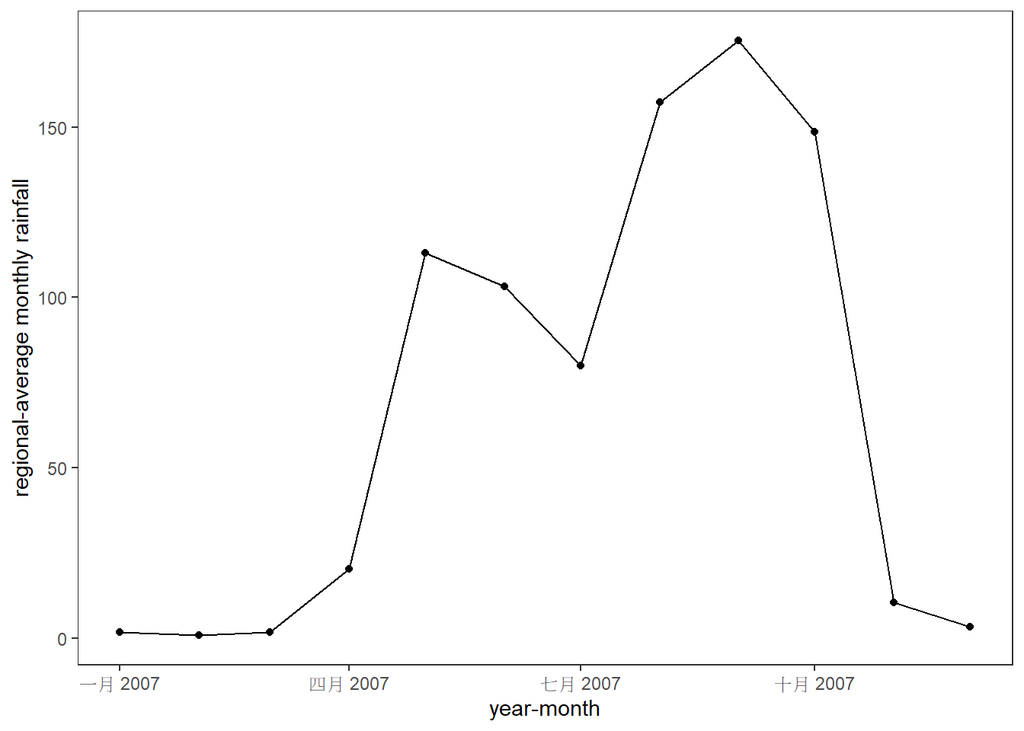

```r
ggplot(df3, aes(ymd(ym), regional_avg)) +
  geom_point() +
  geom_line() +
  labs(x = "year-month", y = "regional-average monthly rainfall") +
  theme_test()
```

(4) Identify… (2pt).

```r
# dry seasons are winter and spring
df3 %>%
  filter(regional_avg < 50) %>%
  pull(ym) %>%
  month()
```

```
#> [1]  1  2  3  4 11 12
```

```r
# wet seasons are summer and fall
df3 %>%
  filter(regional_avg > 50) %>%
  pull(ym) %>%
  month()
```

```
#> [1]  5  6  7  8  9 10
```

2. (30pt)

(1) Plot… (10pt). 2pt for selected stations. 5pt for the plot. 3pt for the x-axis label.

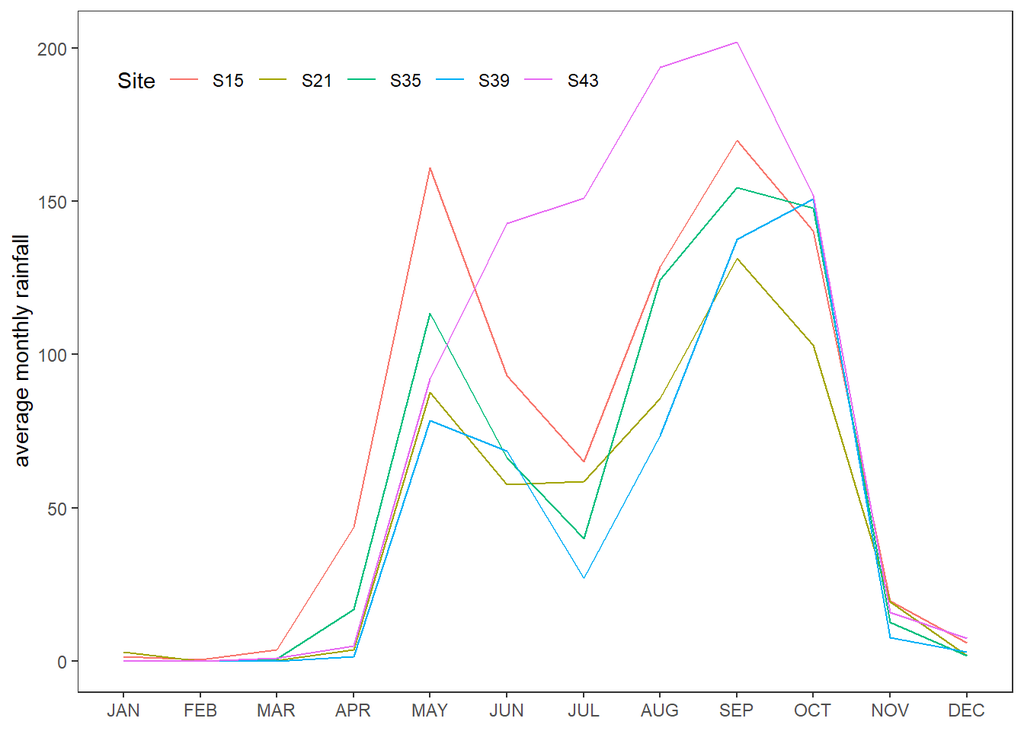

```r
df = read.csv("hw1/Myanmar_Monthly_Rainfall.csv") %>% tibble()
df_pick = df[sample(1:54, 5),] %>%  # randomly pick 5 stations
  pivot_longer(cols = -Site, names_to = "month", values_to = "avg") %>%
  mutate(
    Site = str_c("S", Site),
    month = factor(month, levels = str_to_upper(month.abb)),
  )
ggplot(df_pick, aes(month, avg, color = Site, group = Site)) +
  geom_line() +
  labs(x = NULL, y = "average monthly rainfall") +
  theme_test() +
  theme(
    legend.direction = "horizontal",
    legend.position = c(.3, .9),
  )
```

(2) Plot… (5pt).

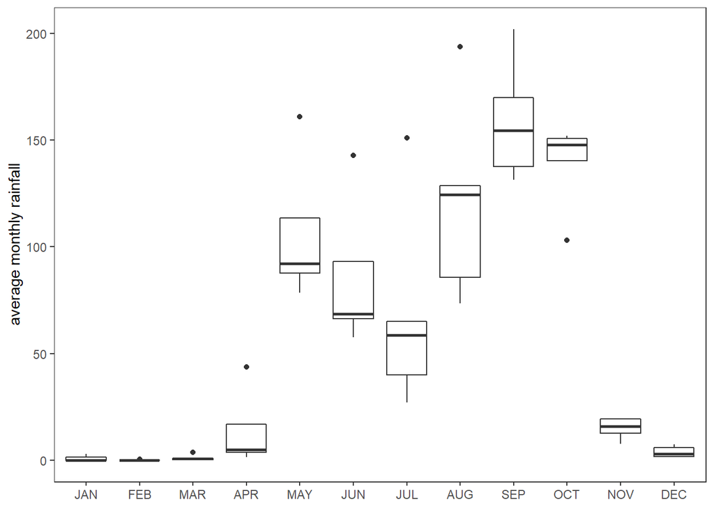

```r
ggplot(df_pick, aes(month, avg)) +
  geom_boxplot() +
  labs(x = NULL, y = "average monthly rainfall") +
  theme_test()
```

(3) Calculate… (10pt).

```r
df_pick %>%
  group_by(month) %>%
  summarise(mean = mean(avg), sd = sd(avg)) %>%
  kable()
```

| month | mean | sd |
| --- | --- | --- |
| JAN | 0.9110133 | 1.3347506 |
| FEB | 0.1185333 | 0.2650486 |
| MAR | 1.1379200 | 1.5072284 |
| APR | 14.1698134 | 17.4954255 |
| MAY | 106.5580800 | 32.9329276 |
| JUN | 85.6657340 | 34.5572622 |
| JUL | 68.3666400 | 48.5694063 |
| AUG | 121.1817080 | 47.0700644 |
| SEP | 159.0717400 | 28.2723773 |
| OCT | 138.7652600 | 20.5288850 |
| NOV | 15.0401866 | 5.0108851 |
| DEC | 4.0335200 | 2.6371839 |

(4) Identify… (5pt). 3pt for the values of outliers. 1pt for the upper whisker and 1pt for the lower whisker.

```r
values = df_pick %>% filter(month == "JUL") %>% pull(avg)
values
```

```
#> [1]  27.19493  58.58933  40.01347 151.01147  65.02400
```

```r
smy = unname(summary(values))
IQR = smy[5] - smy[2]
outliers = values[values > smy[5] + 1.5 * IQR | values < smy[2] - 1.5 * IQR] # values of outliers
outliers
```

```
#> [1] 151.0115
```

```r
min(values[!values %in% outliers]) # lower whisker
```

```
#> [1] 27.19493
```

```r
max(values[!values %in% outliers]) # upper whisker
```

```
#> [1] 65.024
```

3. (20pt)

(1) Calculate… (10pt). Mean 5pt and sd 5 pt.

```r
df = readRDS("hw1/gosat_xco2_East_Asia.rds") %>%
  mutate(
    # ym = format(as.Date(mdate), "%Y-%m"),
    ym = floor_date(as.Date(mdate), unit = "month"),
  ) %>%
  group_by(ym) %>%
  summarise(
    ym = unique(ym),
    mean_co2 = mean(mr.co2),
    sd_co2 = sd(mr.co2),
    .groups = "drop"
  )
kable(df)
```

| ym | mean_co2 | sd_co2 |
| --- | --- | --- |
| 2009-06-01 | 384.3698 | 2.646165 |
| 2009-07-01 | 381.4285 | 3.737220 |
| 2009-08-01 | 380.1686 | 3.249785 |
| 2009-09-01 | 380.7120 | 2.495734 |
| 2009-10-01 | 382.4008 | 2.007268 |
| 2009-11-01 | 384.7146 | 2.035280 |
| 2009-12-01 | 386.6272 | 2.198545 |
| 2010-01-01 | 387.8127 | 2.205396 |
| 2010-02-01 | 388.1147 | 2.049449 |
| 2010-03-01 | 388.9519 | 2.106914 |
| 2010-04-01 | 389.4318 | 2.166095 |
| 2010-05-01 | 388.9075 | 2.142246 |
| 2010-06-01 | 387.0330 | 2.578851 |
| 2010-07-01 | 384.5319 | 3.017742 |
| 2010-08-01 | 383.4096 | 2.933960 |
| 2010-09-01 | 385.4578 | 2.028124 |
| 2010-10-01 | 387.0498 | 2.054972 |
| 2010-11-01 | 388.3970 | 2.067810 |
| 2010-12-01 | 390.2682 | 2.194287 |
| 2011-01-01 | 390.2829 | 1.924218 |
| 2011-02-01 | 390.3090 | 2.180300 |
| 2011-03-01 | 390.8935 | 2.221592 |
| 2011-04-01 | 391.7326 | 2.182249 |
| 2011-05-01 | 391.8086 | 2.292171 |
| 2011-06-01 | 389.1045 | 2.798899 |
| 2011-07-01 | 385.7664 | 3.124443 |
| 2011-08-01 | 385.1421 | 2.771084 |
| 2011-09-01 | 386.7166 | 2.276549 |
| 2011-10-01 | 387.9263 | 2.167692 |
| 2011-11-01 | 389.9559 | 2.024465 |
| 2011-12-01 | 391.6538 | 2.047994 |
| 2012-01-01 | 391.5918 | 2.097341 |
| 2012-02-01 | 392.0782 | 2.399870 |
| 2012-03-01 | 392.5156 | 2.098498 |
| 2012-04-01 | 393.3539 | 2.118433 |
| 2012-05-01 | 393.2398 | 2.338326 |
| 2012-06-01 | 390.7580 | 3.072788 |
| 2012-07-01 | 388.3549 | 3.406234 |
| 2012-08-01 | 387.6135 | 2.706987 |
| 2012-09-01 | 389.0615 | 2.145265 |
| 2012-10-01 | 390.5134 | 2.041203 |
| 2012-11-01 | 392.1984 | 2.139436 |
| 2012-12-01 | 393.9663 | 2.192083 |
| 2013-01-01 | 394.7962 | 2.110912 |
| 2013-02-01 | 394.9586 | 2.068139 |
| 2013-03-01 | 395.1083 | 2.216737 |
| 2013-04-01 | 396.1674 | 2.134609 |
| 2013-05-01 | 396.9496 | 2.326208 |
| 2013-06-01 | 394.7543 | 2.673916 |
| 2013-07-01 | 390.9911 | 3.588313 |
| 2013-08-01 | 390.3963 | 2.854949 |
| 2013-09-01 | 391.7392 | 2.364666 |
| 2013-10-01 | 393.5693 | 2.036461 |
| 2013-11-01 | 395.3970 | 2.161236 |
| 2013-12-01 | 396.7817 | 2.123968 |
| 2014-01-01 | 397.5748 | 2.250715 |
| 2014-02-01 | 397.8158 | 2.214331 |
| 2014-04-01 | 398.7689 | 2.242268 |
| 2014-05-01 | 398.8379 | 2.223666 |
| 2014-06-01 | 394.9702 | 2.606374 |
| 2014-07-01 | 392.8715 | 3.310833 |
| 2014-08-01 | 391.5363 | 2.976895 |
| 2014-09-01 | 392.6348 | 2.346486 |
| 2014-10-01 | 394.5177 | 2.089240 |
| 2014-11-01 | 396.3162 | 2.086347 |
| 2014-12-01 | 397.8685 | 2.243427 |
| 2015-02-01 | 398.7734 | 2.388742 |
| 2015-03-01 | 398.8495 | 2.236524 |
| 2015-04-01 | 399.7603 | 2.426438 |
| 2015-05-01 | 399.9605 | 2.300455 |
| 2015-06-01 | 396.8667 | 2.993428 |
| 2015-07-01 | 394.8665 | 3.157121 |
| 2015-08-01 | 394.0874 | 2.795911 |
| 2015-09-01 | 395.8995 | 2.379479 |
| 2015-10-01 | 397.5033 | 2.304373 |
| 2015-11-01 | 399.6617 | 2.218222 |
| 2015-12-01 | 401.4183 | 2.271543 |
| 2016-01-01 | 402.1188 | 2.450337 |

(2) Plot… (10pt).

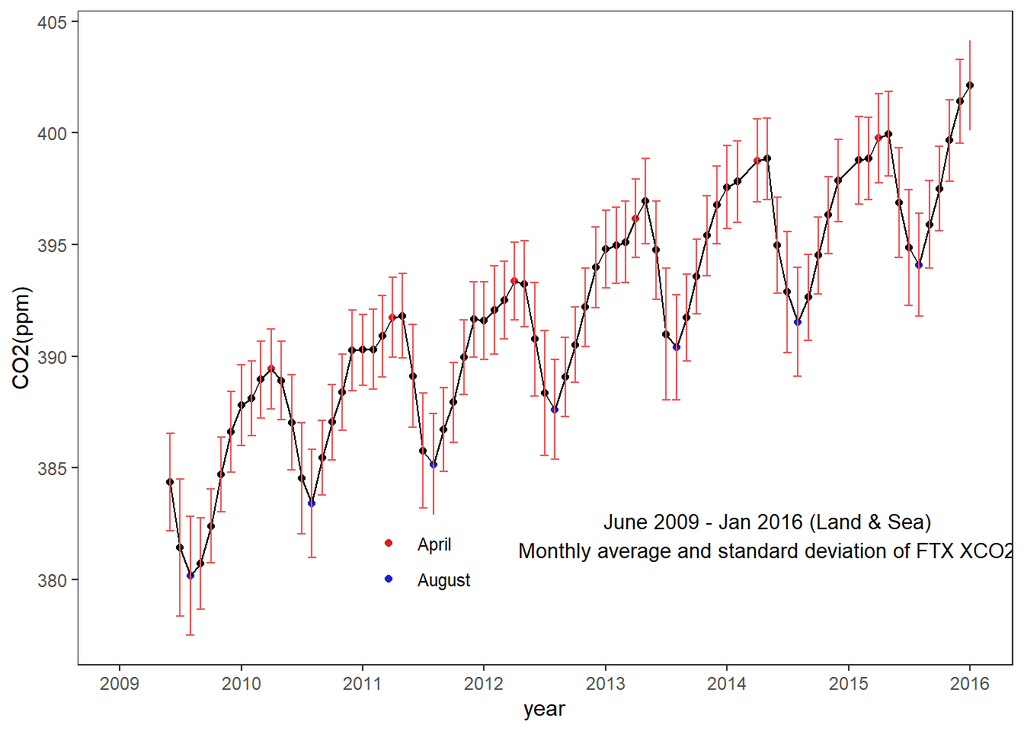

```r
df_48 = df %>% filter(month(ym) %in% c(4, 8))
plt_label = "June 2009 - Jan 2016 (Land & Sea)\nMonthly average and standard deviation of FTX XCO2"
ggplot(df, aes(ym, mean_co2)) +
  geom_point() +
  geom_point(data = df_48, aes(color = factor(month(ym)))) +
  geom_line() +
  geom_errorbar(aes(ymax = mean_co2 + qnorm(0.95) / 2 * sd_co2,
                    ymin = mean_co2 - qnorm(0.95) / 2 * sd_co2),
                color = "#EE5555") +
  annotate(
    geom = "text", x = ymd(20140501), y = 382, size = 3.5,
    label = plt_label
  ) +
  labs(x = "year", y = "CO2(ppm)") +
  scale_x_date(
    date_breaks = "1 year",
    date_minor_breaks = "1 month",
    labels = date_format("%Y"),
    limits = ymd('2009-01-01','2016-01-01')
  ) +
  scale_color_manual(
    name = NULL,
    breaks = c(4, 8),
    labels = c("April", "August"),
    values =c("#E61717", "#1421DE")
  ) +
  theme_test() +
  theme(
    legend.position = c(.42, .23),
    legend.justification = c("right", "top"),
  )
```

4. (20pt)

(1) Plot… (5pt).

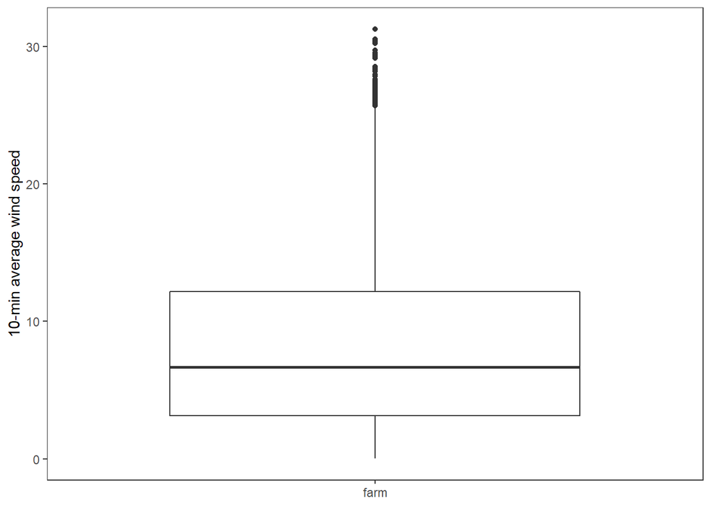

```r
df = read.csv("hw1/Wind_Speed.csv", header = FALSE, col.names = "wind_speed")
df = df %>% mutate(site = "farm")
ggplot(df, aes(site, wind_speed)) +
  geom_boxplot() +
  labs(x = NULL, y = "10-min average wind speed") +
  theme_test()
```

(2) Plot… (5pt).

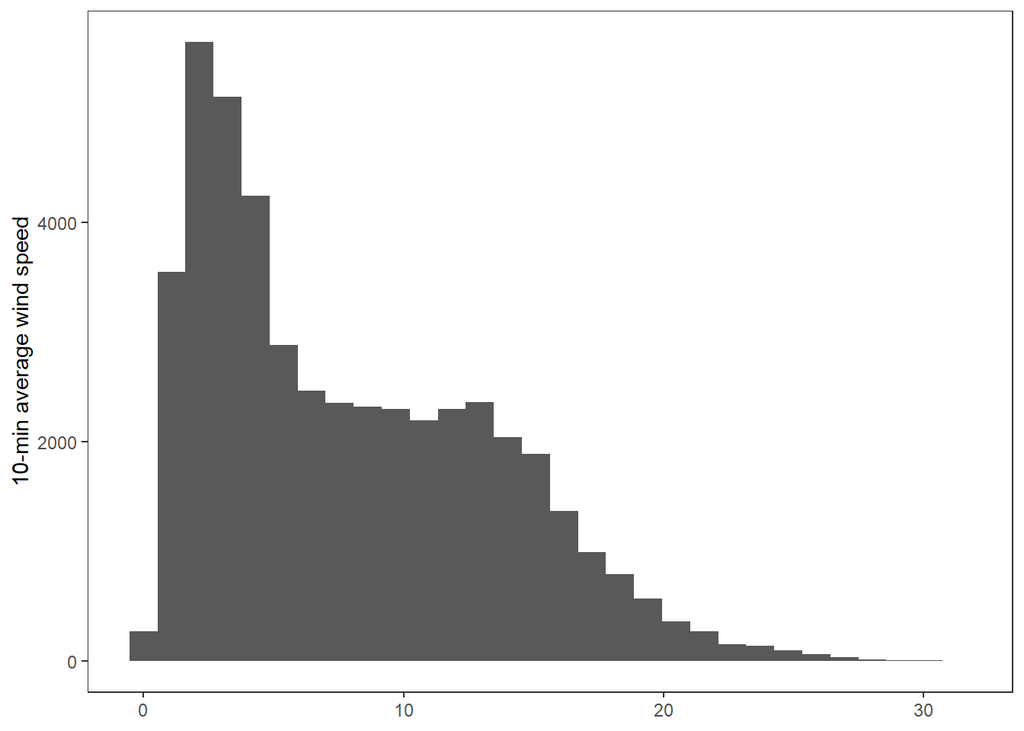

```r
ggplot(df, aes(wind_speed)) +
  geom_histogram() +
  labs(x = NULL, y = "10-min average wind speed") +
  theme_test()
```

(3) Explain… (10pt).

For example, skew to the right.

## 1.5 Appendix: All code for HW1

```r
knitr::opts_chunk$set(echo = FALSE)
knitr::opts_chunk$set(echo = TRUE, comment = "#>", cache = TRUE)
# 3.1
x = c(-43.5615, -42.5594, -27.5556, -24.8670, -7.6353,
      -16.6590, -30.3863, -13.9924, -48.8766, -40.9939,
      -38.2022, -8.6007, -26.9491, -41.7347, -20.3306,
      -16.6453, -8.1240, -6.7680, -14.3989, -37.0406,
      -0.8470, -18.0262, -20.5075, -25.0793, -16.8221,
      -7.7765, 14.4545, 35.3056, 33.6065, -0.1143,
      -0.5319, 7.5514, -0.4998, 14.1964, -0.1449,
      11.8305, 22.5281, 29.9923, 40.7217, 14.2982,
      23.3038, 20.4037, 17.2357, 43.1575, 34.5701,
      33.7827, 31.9995, 23.4265, 18.9954, 13.7399)
# TODO: calculate mean and standard deviation of `x`

# 4.1
x = c(-5.407, -64.317, -18.434, 24.298, -38.989,
      -6.800, -43.550, 31.181, -23.789, -8.363,
      59.050, 32.460, -8.182, -20.621, 14.489,
      -20.165, 2.946, 13.432, 33.898, -43.162,
      -35.052, 46.106, 14.658, 21.340, 13.584,
      16.901, 16.977, 23.161, -38.092, -16.026,
      17.982, 15.979, -20.913, 17.966, 43.496,
      -17.282, -16.295, 9.455, -6.092, -3.146,
      19.561, -37.615, -1.747, -44.600, -38.186,
      -1.586, 65.115, 4.176, 5.509, 38.330)
# TODO: calculate mean and standard deviation of `x`

# 5.1
library(tidyverse)
# TODO: `constant` is the constant c in the question, you have to prove c at first
constant = ____
n = 10000 # target random sample size
# TODO: fill in the number of random sample
df = tibble(
  rexp = rexp(____, 1),
  dexp = constant * dexp(rexp, 1),
  runif = runif(____, min = 0, max = dexp),
  dnorm = 2 * dnorm(rexp),
  reject = dnorm < runif
)
# after filter those not rejected random samples, which represent sampling from truncated normal distribution,
samples = df %>%
  filter(reject == FALSE) %>%
  pull(rexp)
# TODO: you need to give positive or negative sign randomly to random samples
samples = samples[1:n] * sample(c(1, -1), size = n, replace = TRUE)
# TODO: calculate the mean and variance
# TODO: plot the histogram

# Additional code (not necessary to submit)
# demonstrate the acceptance-rejection method
ggplot(df) +
  geom_point(aes(rexp, runif, colour = reject), size = .01) +
  geom_line(aes(rexp, dexp), colour = "darkgreen") +
  geom_line(aes(rexp, dnorm), colour = "darkorange") +
  scale_colour_manual(values = c("lightgoldenrod", "lightgreen"), guide = FALSE) +
  labs(x = "", y = "") +
  theme_classic()
knitr::opts_chunk$set(echo = TRUE, comment = "#>", cache = TRUE)
library(tidyverse)
library(lubridate)
library(scales)
library(knitr)
cubes = rep(c("red", "yellow", "blue"), c(22, 15,13))

sample_space = cubes[which(cubes != "blue")]
# or equivalently,
# sample_space = cubes[which(!cubes %in% "blue")]
# sample_space = cubes[!cubes %in% "blue"]
sample(sample_space, size = 10, replace = TRUE)
sample(sample_space, size = 10, replace = FALSE)
# or equivalently,
# sample(sample_space, size = 10)
f_Z = function(z) {
  case_when(
    z >= 5 & z < 12 ~ 2 / 735 * z - 2 / 147,
    z >= 12 & z < 15 ~ -1 / 1470 * z + 4 / 147,
    z >= 15 & z < 35 ~ 29 / 29400 * z + 13 / 5880,
    z >= 35 & z < 40 ~ -23 / 9800 * z + 233 / 1960,
    z >= 40 & z < 55 ~ -1 / 600 * z + 11 / 120,
    TRUE ~ 0
  )
}
df = tibble(
  z = seq(0, 80, 0.1),
  f_z = f_Z(z),
  F_z = map_dbl(z, ~ integrate(f_Z, 0, .x)$value)
)
ggplot(df, aes(z, f_z)) +
  geom_line() +
  geom_vline(xintercept = c(12, 15, 35, 40), linetype = "dotted") +
  scale_x_continuous(breaks = c(5, 12, 15, 35, 40, 55), name = "z") +
  scale_y_continuous(limits = c(0, 0.1), name = latex2exp::TeX("$\\f_Z(z)$")) +
  theme_test()
# continous code in (1), or separate the c.d.f as follows
# df = df %>%
#   mutate(F_z = map_dbl(z, ~ integrate(f_Z, 0, .x)$value))
ggplot(df, aes(z, F_z)) +
  geom_line() +
  geom_vline(xintercept = c(12, 15, 35, 40), linetype = "dotted") +
  scale_x_continuous(breaks = c(5, 12, 15, 35, 40, 55), name = "z") +
  scale_y_continuous(limits = c(0, 1.0001), name = latex2exp::TeX("$\\F_Z(z)$")) +
  theme_test()
integrate(function(x) {x * 0.4/2.5 * (x - 10)}, 10, 12.5)$value + integrate(function(x) {x * (0.4 - 0.4 / 2.5 * (x - 12.5))}, 12.5, 15)$value
# 法一
integrate(function(x) {(x - 12.5)^2 * 0.4/2.5 *(x - 10)}, 10, 12.5)$value + integrate(function(x) {(x - 12.5)^2 * (0.4 - 0.4 / 2.5 * (x - 12.5))}, 12.5, 15)$value
# 法二
integrate(function(x) {x^2 * 0.4/2.5 * (x - 10)}, 10, 12.5)$value + integrate(function(x) {x^2 * (0.4 - 0.4 / 2.5 * (x - 12.5))}, 12.5, 15)$value - 12.5^2
integrate(function(x) {x * (0.4 - 0.4 / 2.5 * (x - 12.5)) / 0.5}, 12.5, 15)$value
# 法一
integrate(function(x) {(x - 13.3333)^2 * (0.4 - 0.4 / 2.5 * (x - 12.5)) / 0.5}, 12.5, 15)$value
# 法二
integrate(function(x) {x^2 * (0.4 - 0.4 / 2.5 * (x - 12.5)) / 0.5}, 12.5, 15)$value - 13.3333^2
sum(dbinom(c(0:5, 15:20), 20, 0.6))
df = tibble(
  simulation_set = factor(rep(1:5, each = 21)),
  n = rep(0:20, times = 5),
  move = map_dbl(n, ~ case_when(
    .x == 0 ~ 0,
    TRUE ~ sample(c(-1, 1), 1, prob = c(1 - 0.6, 0.6))
  )),
) %>%
  group_by(simulation_set) %>%
  mutate(position = cumsum(move))

ggplot(df, aes(n, position, color = simulation_set)) +
  geom_point() +
  geom_line() +
  scale_x_continuous(name = "time", breaks = seq(0, 20, 1)) +
  scale_y_continuous(name = "distance", breaks = seq(-20, 20, 1)) +
  theme_test()
F_X = function(x) {
  case_when(
    x >= 0 & x < 5 ~ x^2 / 75,
    x >= 5 & x < 15 ~ -1 / 2 + x / 5 - x^2 / 150,
    x >= 15 ~ 1,
    TRUE ~ 0
  )
}
df = tibble(
  x = seq(0, 20, 0.01),
  F_x = F_X(x),
)
ggplot(df, aes(x, F_x)) +
  geom_line() +
  scale_x_continuous(breaks = c(0, 5, 10, 15, 20), name = "x") +
  scale_y_continuous(limits = c(0, 1.0001), name = latex2exp::TeX("$\\F_X(x)$")) +
  theme_test()
F_Y = function(y) {
  case_when(
    y >= 5 & y < 10 ~ y^2 / 50 - y / 5 + 1 / 2,
    y >= 10 & y < 15 ~ -y^2 / 50 + 3 * y / 5 - 7 / 2,
    y >= 15 ~ 1,
    TRUE ~ 0
  )
}
df = tibble(
  y = seq(0, 20, 0.01),
  F_y = F_Y(y),
)
ggplot(df, aes(y, F_y)) +
  geom_line() +
  scale_x_continuous(breaks = c(0, 5, 10, 15, 20), name = "y") +
  scale_y_continuous(limits = c(0, 1.0001), name = latex2exp::TeX("$\\F_Y(y)$")) +
  theme_test()
integrate(function(y) {(3 / 2 - y / 5 + y^2 / 150) * (-1 / 5 + y / 25)}, 5, 10)$value +
  integrate(function(y) {(3 / 2 - y / 5 + y^2 / 150) * (3 / 5 - y / 25)}, 10, 15)$value
knitr::opts_chunk$set(echo = TRUE, comment = "#>", cache = TRUE)
library(tidyverse)
library(lubridate)
library(scales)
library(knitr)
df = read.csv("hw1/raindata.csv") %>% tibble()
df1 = df %>%
  group_by(ym = floor_date(mdy(Date), unit = "month")) %>%
  summarise_if(is.double, sum)
kable(df1)
df2 = df1 %>%
  group_by(month = str_sub(ym, 6, 7)) %>%
  summarise_if(is.double, mean)
kable(select(df2, -ym))
df3 = df2 %>%
  rowwise(month) %>%
  mutate(regional_avg = mean(c_across(Site.A:Site.E))) %>%
  ungroup()
kable(select(df3, month, regional_avg))
ggplot(df3, aes(ymd(ym), regional_avg)) +
  geom_point() +
  geom_line() +
  labs(x = "year-month", y = "regional-average monthly rainfall") +
  theme_test()
# dry seasons are winter and spring
df3 %>%
  filter(regional_avg < 50) %>%
  pull(ym) %>%
  month()
# wet seasons are summer and fall
df3 %>%
  filter(regional_avg > 50) %>%
  pull(ym) %>%
  month()
df = read.csv("hw1/Myanmar_Monthly_Rainfall.csv") %>% tibble()
df_pick = df[sample(1:54, 5),] %>%  # randomly pick 5 stations
  pivot_longer(cols = -Site, names_to = "month", values_to = "avg") %>%
  mutate(
    Site = str_c("S", Site),
    month = factor(month, levels = str_to_upper(month.abb)),
  )
ggplot(df_pick, aes(month, avg, color = Site, group = Site)) +
  geom_line() +
  labs(x = NULL, y = "average monthly rainfall") +
  theme_test() +
  theme(
    legend.direction = "horizontal",
    legend.position = c(.3, .9),
  )
ggplot(df_pick, aes(month, avg)) +
  geom_boxplot() +
  labs(x = NULL, y = "average monthly rainfall") +
  theme_test()
df_pick %>%
  group_by(month) %>%
  summarise(mean = mean(avg), sd = sd(avg)) %>%
  kable()
values = df_pick %>% filter(month == "JUL") %>% pull(avg)
values
smy = unname(summary(values))
IQR = smy[5] - smy[2]
outliers = values[values > smy[5] + 1.5 * IQR | values < smy[2] - 1.5 * IQR] # values of outliers
outliers
min(values[!values %in% outliers]) # lower whisker
max(values[!values %in% outliers]) # upper whisker
df = readRDS("hw1/gosat_xco2_East_Asia.rds") %>%
  mutate(
    # ym = format(as.Date(mdate), "%Y-%m"),
    ym = floor_date(as.Date(mdate), unit = "month"),
  ) %>%
  group_by(ym) %>%
  summarise(
    ym = unique(ym),
    mean_co2 = mean(mr.co2),
    sd_co2 = sd(mr.co2),
    .groups = "drop"
  )
kable(df)
df_48 = df %>% filter(month(ym) %in% c(4, 8))
plt_label = "June 2009 - Jan 2016 (Land & Sea)\nMonthly average and standard deviation of FTX XCO2"
ggplot(df, aes(ym, mean_co2)) +
  geom_point() +
  geom_point(data = df_48, aes(color = factor(month(ym)))) +
  geom_line() +
  geom_errorbar(aes(ymax = mean_co2 + qnorm(0.95) / 2 * sd_co2,
                    ymin = mean_co2 - qnorm(0.95) / 2 * sd_co2),
                color = "#EE5555") +
  annotate(
    geom = "text", x = ymd(20140501), y = 382, size = 3.5,
    label = plt_label
  ) +
  labs(x = "year", y = "CO2(ppm)") +
  scale_x_date(
    date_breaks = "1 year",
    date_minor_breaks = "1 month",
    labels = date_format("%Y"),
    limits = ymd('2009-01-01','2016-01-01')
  ) +
  scale_color_manual(
    name = NULL,
    breaks = c(4, 8),
    labels = c("April", "August"),
    values =c("#E61717", "#1421DE")
  ) +
  theme_test() +
  theme(
    legend.position = c(.42, .23),
    legend.justification = c("right", "top"),
  )
df = read.csv("hw1/Wind_Speed.csv", header = FALSE, col.names = "wind_speed")
df = df %>% mutate(site = "farm")
ggplot(df, aes(site, wind_speed)) +
  geom_boxplot() +
  labs(x = NULL, y = "10-min average wind speed") +
  theme_test()
ggplot(df, aes(wind_speed)) +
  geom_histogram() +
  labs(x = NULL, y = "10-min average wind speed") +
  theme_test()
```

# Info

TA email: r08h41005@ntu.edu.tw

Office: 系館 100 (RSLAB)，無須敲門直接進入詢問即可

Office hour: 五 12:10-14:00

Homework: 作業採紙本繳交，包括數學題、程式碼與程式輸出，助教於課後清點取回批改。遲交一周內$原作業得分\times 0.8$，遲交一周以上未滿兩周則$原作業得分\times 0.8^2$，超過兩周未繳交則不予計分。作業會於繳交後兩周以內批改完並發還，雖然作業會分配給其他助教批改，但會有一致的計分方式。各習題視情況給予詳解或說明。

R: 暫定每三周會有助教介紹 R 的使用，以利同學完成習題，確切時間配合授課老師通知。

Website: 作業解答和其他助教提供的資料將會放在 https://hochia.github.io/bse-statistics/。教授課程網頁 http://www.rslabntu.net/courses/statistics。助教一年前的上機資料 https://hochia.github.io/r-statistics/。